# Supplemental Analysis: GPT-2 Surprisal as Predictability Measure

2026-06-06

## Overview

This document replicates the predictability analyses from the main paper, replacing the n-gram-based log-odds-ratio predictability measure with GPT-2 surprisal. Surprisal is defined as $-\log_e P(\textit{up} \mid \text{context})$, where context consists of all words preceding *up* in the sentence. Higher surprisal indicates that *up* is less predictable given the preceding context (i.e., surprisal is the inverse of predictability).

## GPT-2 Surprisal Computation

GPT-2 surprisal values are computed by `compute_gpt2_surprisal.py` (in this directory) and saved to `../Data/gpt2_surprisal.csv`. Run that script before knitting this document:

```
python compute_gpt2_surprisal.py
```

## Data Preparation

```r
gam_data = read_csv('../Data/gam_data.csv')
gpt2_surprisal = read_csv('../Data/gpt2_surprisal.csv')

gam_data = gam_data %>%
  left_join(gpt2_surprisal %>% select(Item, gpt2_surprisal), by = 'Item') %>%
  filter(!is.na(gpt2_surprisal))

gam_data$participant = as.factor(gam_data$participant)
gam_data$Item        = as.factor(gam_data$Item)
gam_data$Type        = as.factor(gam_data$Type)
gam_data$PhrasalVerb = as.factor(gam_data$PhrasalVerb)

cat("Items with GPT-2 surprisal:", length(unique(gam_data$Item)), "\n")
```

```
## Items with GPT-2 surprisal: 200
```

```r
cat("Surprisal range: [", round(min(gam_data$gpt2_surprisal), 2), ",",
    round(max(gam_data$gpt2_surprisal), 2), "]\n")
```

```
## Surprisal range: [ 0.02 , 7.92 ]
```

## GAM Models

### Model 1: Interaction Between GPT-2 Surprisal and Frequency

This model replicates the model from Equation 1 of the paper, replacing `log_predic` with `gpt2_surprisal`.

$$\begin{aligned}
\log(RT) & \sim te(\text{GPT-2 Surprisal}, \text{Frequency}) + \text{Duration} + s(\text{participant}, bs = \text{`}re\text{'}) \\
& + s(\text{Item}, bs = \text{`}re\text{'}) + s(\text{trial}, bs = \text{`}re\text{'}) \\
& + s(\text{GPT-2 Surprisal}, \text{Frequency}, \text{trial}, \text{participant}, bs = \text{`}re\text{'})
\end{aligned}$$

```r
mod_gam1_gpt2 = bam(log_rt ~
                      te(gpt2_surprisal, log_freq) + Duration +
                      s(trial, bs = 're') +
                      s(participant, bs = 're') +
                      s(Item, bs = 're') +
                      s(gpt2_surprisal, log_freq, trial, participant, bs = 're'),
                    data = gam_data)

summary(mod_gam1_gpt2)
saveRDS(mod_gam1_gpt2, '../Models/mod_gam1_gpt2.rds')
```

```r
surp_seq  = seq(min(gam_data$gpt2_surprisal), max(gam_data$gpt2_surprisal), length.out = 50)
freq_seq  = seq(min(gam_data$log_freq),        max(gam_data$log_freq),        length.out = 50)

pred_grid = expand.grid(gpt2_surprisal = surp_seq, log_freq = freq_seq) %>%
  mutate(Duration    = 0,
         trial       = gam_data$trial[1],
         participant = gam_data$participant[1],
         Item        = gam_data$Item[1])

preds = predict(mod_gam1_gpt2, newdata = pred_grid,
                exclude = c('s(trial)', 's(participant)', 's(Item)',
                            's(gpt2_surprisal,log_freq,trial,participant)'))

z_mat = matrix(preds, nrow = length(surp_seq), ncol = length(freq_seq))

plot_ly(x = surp_seq, y = freq_seq, z = z_mat,
        type = 'surface', colorscale = 'Viridis') %>%
  layout(scene = list(
    xaxis = list(title = 'GPT-2 Surprisal'),
    yaxis = list(title = 'Log Frequency'),
    zaxis = list(title = 'Predicted Log RT')
  ))
```

```r
re_exclude_gam1 = c('s(trial)', 's(participant)', 's(Item)',
                    's(gpt2_surprisal,log_freq,trial,participant)')

slice_surp = tibble(
  gpt2_surprisal = seq(min(gam_data$gpt2_surprisal), max(gam_data$gpt2_surprisal), length.out = 200),
  log_freq       = mean(gam_data$log_freq),
  Duration       = 0,
  trial          = gam_data$trial[1],
  participant    = gam_data$participant[1],
  Item           = gam_data$Item[1]
)
preds_s = predict(mod_gam1_gpt2, newdata = slice_surp, se.fit = TRUE, exclude = re_exclude_gam1)
slice_surp = slice_surp %>% mutate(fit = preds_s$fit, se = preds_s$se.fit)

slice_freq = tibble(
  log_freq       = seq(min(gam_data$log_freq), max(gam_data$log_freq), length.out = 200),
  gpt2_surprisal = mean(gam_data$gpt2_surprisal),
  Duration       = 0,
  trial          = gam_data$trial[1],
  participant    = gam_data$participant[1],
  Item           = gam_data$Item[1]
)
preds_f = predict(mod_gam1_gpt2, newdata = slice_freq, se.fit = TRUE, exclude = re_exclude_gam1)
slice_freq = slice_freq %>% mutate(fit = preds_f$fit, se = preds_f$se.fit)

p1_surp = ggplot(slice_surp, aes(x = gpt2_surprisal, y = fit)) +
  geom_ribbon(aes(ymin = fit - se, ymax = fit + se), alpha = 0.3) +
  geom_line() +
  xlab('GPT-2 Surprisal\n(frequency at mean)') + ylab('Predicted Log RT') +
  theme_bw()

p1_freq = ggplot(slice_freq, aes(x = log_freq, y = fit)) +
  geom_ribbon(aes(ymin = fit - se, ymax = fit + se), alpha = 0.3) +
  geom_line() +
  xlab('Log Frequency\n(surprisal at mean)') + ylab('Predicted Log RT') +
  theme_bw()

ggarrange(p1_surp, p1_freq, nrow = 1)

rm(mod_gam1_gpt2, slice_surp, slice_freq, preds_s, preds_f, p1_surp, p1_freq); gc()
```

### Model 2: Phrasal vs. Non-Phrasal Verbs

This model replicates the model from Equation 2 of the paper, replacing `log_predic` with `gpt2_surprisal`.

$$\begin{aligned}
\log(RT) & \sim te(\text{GPT-2 Surprisal}, \text{Frequency}, \text{by} = \text{PhrasalVerb}) + \text{Duration} \\
& + s(\text{participant}, bs = \text{`}re\text{'}) + s(\text{Item}, bs = \text{`}re\text{'}) + s(\text{trial}, bs = \text{`}re\text{'}) \\
& + s(\text{GPT-2 Surprisal}, \text{Frequency}, \text{trial}, \text{participant}, bs = \text{`}re\text{'})
\end{aligned}$$

```r
mod_gam_phrasal_nonphrasal_gpt2 = bam(log_rt ~
                                        PhrasalVerb +
                                        te(gpt2_surprisal, log_freq, by = PhrasalVerb) + Duration +
                                        s(trial, bs = 're') +
                                        s(participant, bs = 're') +
                                        s(Item, bs = 're') +
                                        s(gpt2_surprisal, log_freq, trial, participant, bs = 're'),
                                      data = gam_data)

summary(mod_gam_phrasal_nonphrasal_gpt2)
saveRDS(mod_gam_phrasal_nonphrasal_gpt2, '../Models/mod_gam_phrasal_nonphrasal_gpt2.rds')
```

```r
pred_grid_nonphrasal = pred_grid %>%
  mutate(PhrasalVerb = factor('nonphrasal', levels = levels(gam_data$PhrasalVerb)))

pred_grid_phrasal = pred_grid %>%
  mutate(PhrasalVerb = factor('phrasal', levels = levels(gam_data$PhrasalVerb)))

re_exclude = c('s(trial)', 's(participant)', 's(Item)',
               's(gpt2_surprisal,log_freq,trial,participant)')

preds_nonphrasal = predict(mod_gam_phrasal_nonphrasal_gpt2,
                           newdata = pred_grid_nonphrasal, exclude = re_exclude)
preds_phrasal    = predict(mod_gam_phrasal_nonphrasal_gpt2,
                           newdata = pred_grid_phrasal,    exclude = re_exclude)

z_nonphrasal = matrix(preds_nonphrasal, nrow = length(surp_seq), ncol = length(freq_seq))
z_phrasal    = matrix(preds_phrasal,    nrow = length(surp_seq), ncol = length(freq_seq))

scene_spec = list(xaxis = list(title = 'GPT-2 Surprisal'),
                  yaxis = list(title = 'Log Frequency'),
                  zaxis = list(title = 'Predicted Log RT'))

p_nonphrasal = plot_ly(x = surp_seq, y = freq_seq, z = z_nonphrasal,
                       type = 'surface', colorscale = 'Viridis', showscale = FALSE) %>%
  layout(title = 'Non-phrasal verbs', scene = scene_spec)

p_phrasal = plot_ly(x = surp_seq, y = freq_seq, z = z_phrasal,
                    type = 'surface', colorscale = 'Viridis', showscale = FALSE) %>%
  layout(title = 'Phrasal verbs', scene = scene_spec)

p_nonphrasal
p_phrasal
```

```r
conditions = c('nonphrasal', 'phrasal')

slice_plots = lapply(conditions, function(cond) {
  base = tibble(Duration    = 0,
                trial       = gam_data$trial[1],
                participant = gam_data$participant[1],
                Item        = gam_data$Item[1],
                PhrasalVerb = factor(cond, levels = levels(gam_data$PhrasalVerb)))

  s_data = base %>%
    slice(rep(1, 200)) %>%
    mutate(gpt2_surprisal = seq(min(gam_data$gpt2_surprisal), max(gam_data$gpt2_surprisal), length.out = 200),
           log_freq       = mean(gam_data$log_freq))
  ps = predict(mod_gam_phrasal_nonphrasal_gpt2, newdata = s_data, se.fit = TRUE, exclude = re_exclude)
  s_data = s_data %>% mutate(fit = ps$fit, se = ps$se.fit)

  f_data = base %>%
    slice(rep(1, 200)) %>%
    mutate(log_freq       = seq(min(gam_data$log_freq), max(gam_data$log_freq), length.out = 200),
           gpt2_surprisal = mean(gam_data$gpt2_surprisal))
  pf = predict(mod_gam_phrasal_nonphrasal_gpt2, newdata = f_data, se.fit = TRUE, exclude = re_exclude)
  f_data = f_data %>% mutate(fit = pf$fit, se = pf$se.fit)

  ps_plot = ggplot(s_data, aes(x = gpt2_surprisal, y = fit)) +
    geom_ribbon(aes(ymin = fit - se, ymax = fit + se), alpha = 0.3) +
    geom_line() +
    xlab('GPT-2 Surprisal\n(frequency at mean)') + ylab('Predicted Log RT') +
    ggtitle(paste0(tools::toTitleCase(cond), ' verbs')) +
    theme_bw()

  pf_plot = ggplot(f_data, aes(x = log_freq, y = fit)) +
    geom_ribbon(aes(ymin = fit - se, ymax = fit + se), alpha = 0.3) +
    geom_line() +
    xlab('Log Frequency\n(surprisal at mean)') + ylab('Predicted Log RT') +
    ggtitle(paste0(tools::toTitleCase(cond), ' verbs')) +
    theme_bw()

  list(surp = ps_plot, freq = pf_plot)
})

ggarrange(slice_plots[[1]]$surp, slice_plots[[1]]$freq,
          slice_plots[[2]]$surp, slice_plots[[2]]$freq,
          nrow = 2, ncol = 2)

rm(mod_gam_phrasal_nonphrasal_gpt2, pred_grid, pred_grid_nonphrasal, pred_grid_phrasal,
   slice_plots, preds_nonphrasal, preds_phrasal, z_nonphrasal, z_phrasal); gc()
```

### Model 3: Main Effects and Interaction (ti() terms)

This model replicates the model from Equation 3 of the paper, replacing `log_predic` with `gpt2_surprisal`.

$$\begin{aligned}
\log(RT) & \sim ti(\text{Frequency}) + ti(\text{GPT-2 Surprisal}) + ti(\text{GPT-2 Surprisal}, \text{Frequency}) \\
& + \text{Duration} + s(\text{participant}, bs = \text{`}re\text{'}) + s(\text{Item}, bs = \text{`}re\text{'}) \\
& + s(\text{GPT-2 Surprisal}, \text{Frequency}, \text{participant}, bs = \text{`}re\text{'})
\end{aligned}$$

```r
mod_bam_inter_gpt2 = bam(log_rt ~
                           ti(log_freq) + ti(gpt2_surprisal) + ti(gpt2_surprisal, log_freq) +
                           Duration +
                           s(participant, bs = 're') +
                           s(Item, bs = 're') +
                           s(gpt2_surprisal, log_freq, participant, bs = 're'),
                         method = 'REML',
                         data = gam_data)

summary(mod_bam_inter_gpt2)
saveRDS(mod_bam_inter_gpt2, '../Models/mod_bam_inter_gpt2.rds')
```

```r
nd_base = tibble(Duration = 0, log_freq = 0, gpt2_surprisal = 0, participant = 0, Item = 0)

nd_surp = nd_base %>%
  slice(rep(1, 1000)) %>%
  mutate(gpt2_surprisal = seq(min(gam_data$gpt2_surprisal), max(gam_data$gpt2_surprisal), length.out = 1000))
nd_surp = predict(mod_bam_inter_gpt2, newdata = nd_surp, se = TRUE, terms = 'ti(gpt2_surprisal)') %>%
  as_tibble() %>% cbind(nd_surp)

nd_freq = nd_base %>%
  slice(rep(1, 1000)) %>%
  mutate(log_freq = seq(min(gam_data$log_freq), max(gam_data$log_freq), length.out = 1000))
nd_freq = predict(mod_bam_inter_gpt2, newdata = nd_freq, se = TRUE, terms = 'ti(log_freq)') %>%
  as_tibble() %>% cbind(nd_freq)

p3_surp = ggplot(nd_surp, aes(x = gpt2_surprisal, y = fit)) +
  geom_ribbon(aes(ymin = fit - se.fit, ymax = fit + se.fit), alpha = 0.3) +
  geom_line() +
  xlab('GPT-2 Surprisal of "up"') + ylab('Predicted Effect on Recognition Time') +
  theme_bw()

p3_freq = ggplot(nd_freq, aes(x = log_freq, y = fit)) +
  geom_ribbon(aes(ymin = fit - se.fit, ymax = fit + se.fit), alpha = 0.3) +
  geom_line() +
  xlab('Log Frequency') + ylab('Predicted Effect on Recognition Time') +
  theme_bw()

ggarrange(p3_surp, p3_freq, nrow = 1)

rm(mod_bam_inter_gpt2, nd_base, nd_surp, nd_freq, p3_surp, p3_freq); gc()
```

## Bayesian Quadratic Models

All Bayesian models in this document are launched simultaneously in parallel using the `future` package (8 workers, 4 chains each). Models are cached to disk via the `file =` argument and loaded on subsequent knits without re-running.

### Full Model: Frequency and GPT-2 Surprisal

This model replicates Equation 4 of the paper, replacing `log_predic` with `gpt2_surprisal`.

$$\begin{aligned}
\log(RT) & \sim \log(\text{Frequency}) + \text{GPT-2 Surprisal} + \text{Duration} \\
& + \log(\text{Frequency})^2 + \text{GPT-2 Surprisal}^2 \\
& + (1 + \log(\text{Frequency}) + \text{GPT-2 Surprisal} + \log(\text{Frequency})^2 \\
& \quad + \text{GPT-2 Surprisal}^2 + \text{Duration} \mid\mid \text{Participant}) + (1 \mid\mid \text{Item})
\end{aligned}$$

```r
brms_gpt2_quadratic_no_interaction = value(future_gpt2_full)

fixef(brms_gpt2_quadratic_no_interaction)
```

```r
percent_greater_zero = data.frame(fixef(brms_gpt2_quadratic_no_interaction, summary = FALSE)) %>%
  pivot_longer(cols = everything(), names_to = 'beta_coefficient', values_to = 'estimate') %>%
  group_by(beta_coefficient) %>%
  summarize(pct_gt_zero = (sum(estimate > 0) / n()) * 100)

percent_greater_zero
```

```r
brms_gpt2_plot = conditional_effects(brms_gpt2_quadratic_no_interaction)

freq_plot_gpt2 = plot(brms_gpt2_plot, plot = FALSE)[[1]] +
  ylab('Log Reaction Time') + xlab('Log Frequency') + theme_bw()

surprisal_plot_gpt2 = plot(brms_gpt2_plot, plot = FALSE)[[2]] +
  ylab('Log Reaction Time') + xlab('GPT-2 Surprisal of "up"') + theme_bw()

ggarrange(freq_plot_gpt2, surprisal_plot_gpt2, nrow = 2, ncol = 1)
```

```r
beta_coef_labels = list.reverse(c('GPT-2 Surprisal', 'log-frequency', 'Intercept',
                                   'GPT-2 Surprisal^2', 'log-frequency^2'))
brms_gpt2_quadratic_no_interaction %>%
  gather_draws(b_Intercept, b_log_freq, b_gpt2_surprisal,
               b_Igpt2_surprisalE2, b_Ilog_freqE2) %>%
  ggplot(aes(x = .value, y = .variable)) +
  stat_halfeye() +
  xlab('Posterior Distribution') +
  ylab('Beta Coefficient') +
  scale_y_discrete(labels = beta_coef_labels) +
  theme_bw()

rm(brms_gpt2_quadratic_no_interaction, brms_gpt2_plot,
   freq_plot_gpt2, surprisal_plot_gpt2, percent_greater_zero); gc()
```

### GPT-2 Surprisal-Only Model

This model replicates Equation 5 of the paper (the predictability-only quadratic), replacing `log_predic` with `gpt2_surprisal`.

$$\begin{aligned}
\log(RT) & \sim \text{GPT-2 Surprisal} + \text{Duration} + \text{GPT-2 Surprisal}^2 \\
& + (1 + \text{GPT-2 Surprisal} + \text{GPT-2 Surprisal}^2 + \text{Duration} \mid\mid \text{Participant}) + (1 \mid\mid \text{Item})
\end{aligned}$$

```r
brms_gpt2_surprisal_quadratic = value(future_gpt2_only)

fixef(brms_gpt2_surprisal_quadratic)
```

```r
post_samples_surprisal = as.data.frame(fixef(brms_gpt2_surprisal_quadratic, summary = FALSE)) %>%
  select(gpt2_surprisal, Igpt2_surprisalE2)

cat("% samples gpt2_surprisal^2 > 0:",
    round(sum(post_samples_surprisal$Igpt2_surprisalE2 > 0) /
            nrow(post_samples_surprisal) * 100, 1), "\n")

cat("% samples gpt2_surprisal > 0:",
    round(sum(post_samples_surprisal$gpt2_surprisal > 0) /
            nrow(post_samples_surprisal) * 100, 1), "\n")
```

```r
brms_surprisal_only_plot = conditional_effects(brms_gpt2_surprisal_quadratic)

plot(brms_surprisal_only_plot, plot = FALSE)[[1]] +
  ylab('Log Reaction Time') +
  xlab('GPT-2 Surprisal of "up"') +
  theme_bw()
```

```r
beta_coef_labels_surp = list.reverse(c('GPT-2 Surprisal', 'Intercept', 'GPT-2 Surprisal^2'))
brms_gpt2_surprisal_quadratic %>%
  gather_draws(b_Intercept, b_gpt2_surprisal, b_Igpt2_surprisalE2) %>%
  ggplot(aes(x = .value, y = .variable)) +
  stat_halfeye() +
  xlab('Posterior Distribution') +
  ylab('Beta Coefficient') +
  scale_y_discrete(labels = beta_coef_labels_surp) +
  theme_bw()

rm(brms_gpt2_surprisal_quadratic, brms_surprisal_only_plot,
   post_samples_surprisal, gam_data); gc()
```

# Robustness Check: Correlated Random Effects with LKJ Priors

A reviewer noted that removing random-effect correlations (via `||`) for computational tractability is suboptimal and that LKJ priors on the correlation parameters would be preferable. The following models replicate the three Bayesian quadratic regression models from the paper with two changes: (1) random effects are allowed to correlate (using `|` instead of `||`), and (2) an LKJ(2) prior is placed on the correlation matrix. LKJ(2) is a weakly regularizing prior that places slightly more mass on near-identity matrices than the uniform LKJ(1), which helps with convergence while remaining diffuse.

All other model specifications (fixed effects, remaining priors, iterations) are identical to the original models.

```r
# priors_lkj and gam_data_orig are defined in the brms-launch chunk above
options(contrasts = c("contr.sum", "contr.sum"))
```

## Full Model: Frequency and Predictability with LKJ Priors

```r
brms_quadratic_lkj = value(future_lkj_full)

fixef(brms_quadratic_lkj)
```

```
##                   Estimate   Est.Error          Q2.5        Q97.5
## Intercept     -0.105058329 0.030030037 -1.640401e-01 -0.046459826
## log_freq       0.020159732 0.010936544 -1.317997e-03  0.041536994
## log_predic     0.010205611 0.011436792 -1.204981e-02  0.032848108
## Duration      -0.086418180 0.098402003 -2.786957e-01  0.106308914
## Ilog_predicE2  0.003422906 0.001765835 -2.452615e-05  0.006898692
## Ilog_freqE2    0.005472711 0.003607207 -1.658720e-03  0.012502650
```

```r
percent_greater_zero_lkj = data.frame(fixef(brms_quadratic_lkj, summary = FALSE)) %>%
  pivot_longer(cols = everything(), names_to = 'beta_coefficient', values_to = 'estimate') %>%
  group_by(beta_coefficient) %>%
  summarize(pct_gt_zero = (sum(estimate > 0) / n()) * 100)

percent_greater_zero_lkj
```

```
## # A tibble: 6 x 2
##   beta_coefficient pct_gt_zero
##   <chr>                  <dbl>
## 1 Duration             19.0
## 2 Ilog_freqE2          93.5
## 3 Ilog_predicE2        97.4
## 4 Intercept             0.0233
## 5 log_freq             96.8
## 6 log_predic           81.6
```

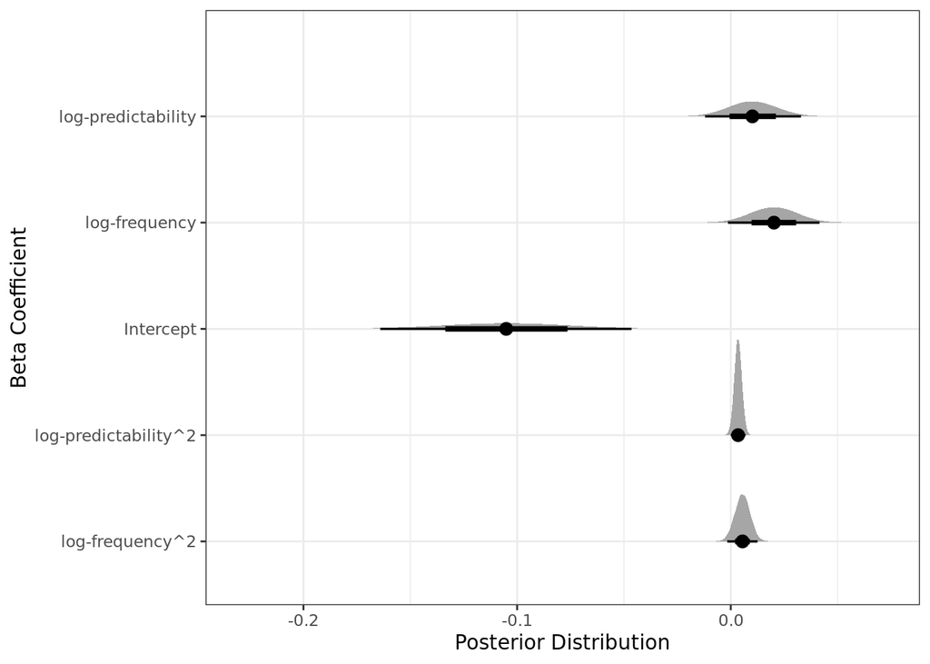

```r
beta_coef_labels_lkj = list.reverse(c('log-predictability', 'log-frequency', 'Intercept',
                                       'log-predictability^2', 'log-frequency^2'))
brms_quadratic_lkj %>%
  gather_draws(b_Intercept, b_log_freq, b_log_predic, b_Ilog_predicE2, b_Ilog_freqE2) %>%
  ggplot(aes(x = .value, y = .variable)) +
  stat_halfeye() +
  xlab('Posterior Distribution') +
  ylab('Beta Coefficient') +
  scale_y_discrete(labels = beta_coef_labels_lkj) +
  theme_bw()
```

```r
rm(brms_quadratic_lkj, percent_greater_zero_lkj); gc()
```

```
##             used   (Mb) gc trigger   (Mb)  max used   (Mb)
## Ncells   4573768  244.3    6725248  359.2   6725248  359.2
## Vcells 259391326 1979.0  702387452 5358.8 877984315 6698.5
```

## Frequency-Only Model with LKJ Priors

```r
brms_freq_quadratic_lkj = value(future_lkj_freq)

fixef(brms_freq_quadratic_lkj)
```

```
##                Estimate   Est.Error          Q2.5       Q97.5
## Intercept   -0.10187217 0.024875794 -0.1506976592 -0.05262507
## log_freq     0.01662039 0.011027018 -0.0050198799  0.03834462
## Duration    -0.08394180 0.097910250 -0.2771967284  0.10842441
## Ilog_freqE2  0.00622806 0.003633616 -0.0008649075  0.01338065
```

```r
post_samples_freq_lkj = as.data.frame(fixef(brms_freq_quadratic_lkj, summary = FALSE)) %>%
  select(log_freq, Ilog_freqE2)

cat("% samples log_freq^2 > 0:",
    round(sum(post_samples_freq_lkj$Ilog_freqE2 > 0) / nrow(post_samples_freq_lkj) * 100, 1), "\n")
```

```
## % samples log_freq^2 > 0: 95.8
```

```r
cat("% samples log_freq > 0:",
    round(sum(post_samples_freq_lkj$log_freq > 0) / nrow(post_samples_freq_lkj) * 100, 1), "\n")
```

```
## % samples log_freq > 0: 93.5
```

```r
rm(brms_freq_quadratic_lkj, post_samples_freq_lkj); gc()
```

```
##             used   (Mb) gc trigger   (Mb)  max used   (Mb)
## Ncells   5061899  270.4    9436887  504.0   6725248  359.2
## Vcells 353284744 2695.4  702387452 5358.8 877984315 6698.5
```

## Predictability-Only Model with LKJ Priors

```r
brms_predic_quadratic_lkj = value(future_lkj_predic)

fixef(brms_predic_quadratic_lkj)
```

```
##                   Estimate   Est.Error          Q2.5        Q97.5
## Intercept     -0.108348742 0.026470835 -0.1598178628 -0.056355589
## log_predic     0.007131493 0.011138400 -0.0146157734  0.028990916
## Duration      -0.090124690 0.097521659 -0.2805966926  0.100907946
## Ilog_predicE2  0.002864399 0.001677976 -0.0004217688  0.006164642
```

```r
post_samples_predic_lkj = as.data.frame(fixef(brms_predic_quadratic_lkj, summary = FALSE)) %>%
  select(log_predic, Ilog_predicE2)

cat("% samples log_predic^2 > 0:",
    round(sum(post_samples_predic_lkj$Ilog_predicE2 > 0) / nrow(post_samples_predic_lkj) * 100, 1), "\n")
```

```
## % samples log_predic^2 > 0: 95.6
```

```r
cat("% samples log_predic > 0:",
    round(sum(post_samples_predic_lkj$log_predic > 0) / nrow(post_samples_predic_lkj) * 100, 1), "\n")
```

```
## % samples log_predic > 0: 74
```

```r
rm(brms_predic_quadratic_lkj, post_samples_predic_lkj); gc()
```

```
##             used   (Mb) gc trigger   (Mb)  max used   (Mb)
## Ncells   5718847  305.5    9436887  504.0   6725248  359.2
## Vcells 470669094 3591.0  702387452 5358.8 877984315 6698.5
```

# Local Context Analyses: Log Conditional Probability and PMI

These analyses replicate the predictability analyses from the main paper, replacing the log-odds-ratio predictability measure with log conditional probability $\log P(\textit{up} \mid V)$ and pointwise mutual information (PMI). Both measures quantify the strength of the local bigram association between the verb and *up* in the corpus, independent of sentential context.

## Relationship Between Measures

The `Predictability` column in the dataset is the bigram odds ratio $\text{Odds}(up \mid V) = P(up \mid V) / (1 - P(up \mid V))$. The log conditional probability is obtained via the logistic transform of the log-odds:

$$\log P(up \mid V) = \log\!\left(\frac{\text{Odds}}{1 + \text{Odds}}\right)$$

PMI is defined as:

$$\text{PMI}(V,\, up) = \log \frac{P(V,\, up)}{P(V)\,P(up)} = \log P(up \mid V) - \log P(up)$$

Because $\log P(up)$ is a corpus-level constant (frequency of *up* = 594,602,106; corpus size = 1,064,909,866,902), PMI and $\log P(up \mid V)$ are perfectly collinear and produce identical regression results (same slopes, different intercept). Models below use $\log P(up \mid V)$; PMI values are reported for descriptive completeness.

## Data Preparation

```r
# gam_data_local (with log_cond_prob and log_pmi) is built in the brms-launch chunk above
cat("log P(up) =", round(log_p_up, 4), "\n")
```

```
## log P(up) = -7.4905
```

```r
cat("PMI offset from log P(up|V):", round(-log_p_up, 4), "\n")
```

```
## PMI offset from log P(up|V): 7.4905
```

```r
cat("log_cond_prob range: [",
    round(min(gam_data_local$log_cond_prob, na.rm = TRUE), 3), ",",
    round(max(gam_data_local$log_cond_prob, na.rm = TRUE), 3), "]\n")
```

```
## log_cond_prob range: [ -8.473 , -0.109 ]
```

```r
cat("log_pmi range: [",
    round(min(gam_data_local$log_pmi, na.rm = TRUE), 3), ",",
    round(max(gam_data_local$log_pmi, na.rm = TRUE), 3), "]\n")
```

```
## log_pmi range: [ -0.983 , 7.381 ]
```

```r
cat("Pearson r(log_cond_prob, log_predic):",
    round(cor(gam_data_local$log_cond_prob, gam_data_local$log_predic,
              use = "complete.obs"), 4), "\n")
```

```
## Pearson r(log_cond_prob, log_predic): 0.9899
```

```r
cat("Pearson r(log_cond_prob, log_freq):",
    round(cor(gam_data_local$log_cond_prob, gam_data_local$log_freq,
              use = "complete.obs"), 4), "\n")
```

```
## Pearson r(log_cond_prob, log_freq): 0.188
```

## GAM Models

### Model 1: Interaction Between Log Conditional Probability and Frequency

This model replicates the model from Equation 1 of the paper, replacing `log_predic` with `log_cond_prob`.

$$\begin{aligned}
\log(RT) & \sim te(\log P(up \mid V),\, \text{Frequency}) + \text{Duration} + s(\text{participant}, bs = \text{`}re\text{'}) \\
& + s(\text{Item}, bs = \text{`}re\text{'}) + s(\text{trial}, bs = \text{`}re\text{'}) \\
& + s(\log P(up \mid V),\, \text{Frequency},\, \text{trial},\, \text{participant}, bs = \text{`}re\text{'})
\end{aligned}$$

```r
mod_gam1_cond_prob = bam(log_rt ~
                           te(log_cond_prob, log_freq) + Duration +
                           s(trial, bs = 're') +
                           s(participant, bs = 're') +
                           s(Item, bs = 're') +
                           s(log_cond_prob, log_freq, trial, participant, bs = 're'),
                         data = gam_data_local)

summary(mod_gam1_cond_prob)
```

```
##
## Family: gaussian
## Link function: identity
##
## Formula:
## log_rt ~ te(log_cond_prob, log_freq) + Duration + s(trial, bs = "re") +
##     s(participant, bs = "re") + s(Item, bs = "re") + s(log_cond_prob,
##     log_freq, trial, participant, bs = "re")
##
## Parametric coefficients:
##              Estimate Std. Error t value Pr(>|t|)
## (Intercept)  0.009288   0.040981   0.227    0.821
## Duration    -1.835479   0.431952  -4.249 2.15e-05 ***
## ---
## Signif. codes:  0 '***' 0.001 '**' 0.01 '*' 0.05 '.' 0.1 ' ' 1
##
## Approximate significance of smooth terms:
##                                                  edf Ref.df       F p-value
## te(log_cond_prob,log_freq)                    5.4383   5.57   1.995  0.0630 .
## s(trial)                                      0.9856   1.00 117.657  <2e-16 ***
## s(participant)                              295.7433 305.00  41.635  <2e-16 ***
## s(Item)                                     175.5453 195.00  10.676  <2e-16 ***
## s(log_cond_prob,log_freq,trial,participant)  61.7168 306.00   1.050  0.0177 *
## ---
## Signif. codes:  0 '***' 0.001 '**' 0.01 '*' 0.05 '.' 0.1 ' ' 1
##
## R-sq.(adj) =  0.334   Deviance explained = 34.8%
## fREML =  17312  Scale est. = 0.20445   n = 26347
```

```r
saveRDS(mod_gam1_cond_prob, '../Models/mod_gam1_cond_prob.rds')
```

```r
cond_seq  = seq(min(gam_data_local$log_cond_prob), max(gam_data_local$log_cond_prob), length.out = 50)
freq_seq2 = seq(min(gam_data_local$log_freq),       max(gam_data_local$log_freq),       length.out = 50)

pred_grid_cp = expand.grid(log_cond_prob = cond_seq, log_freq = freq_seq2) %>%
  mutate(Duration    = 0,
         trial       = gam_data_local$trial[1],
         participant = gam_data_local$participant[1],
         Item        = gam_data_local$Item[1])

preds_cp = predict(mod_gam1_cond_prob, newdata = pred_grid_cp,
                   exclude = c('s(trial)', 's(participant)', 's(Item)',
                               's(log_cond_prob,log_freq,trial,participant)'))

z_mat_cp = matrix(preds_cp, nrow = length(cond_seq), ncol = length(freq_seq2))

plot_ly(x = cond_seq, y = freq_seq2, z = z_mat_cp,
        type = 'surface', colorscale = 'Viridis') %>%
  layout(scene = list(
    xaxis = list(title = 'Log P(up|V)'),
    yaxis = list(title = 'Log Frequency'),
    zaxis = list(title = 'Predicted Log RT')
  ))
```

[interactive chart not shown]

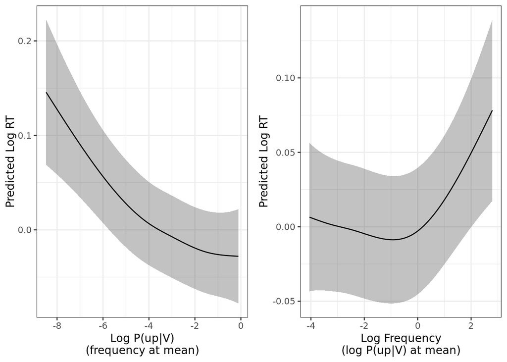

```r
re_excl_cp1 = c('s(trial)', 's(participant)', 's(Item)',
                's(log_cond_prob,log_freq,trial,participant)')

slice_cp = tibble(
  log_cond_prob = seq(min(gam_data_local$log_cond_prob), max(gam_data_local$log_cond_prob), length.out = 200),
  log_freq      = mean(gam_data_local$log_freq),
  Duration      = 0,
  trial         = gam_data_local$trial[1],
  participant   = gam_data_local$participant[1],
  Item          = gam_data_local$Item[1]
)
preds_cp_s = predict(mod_gam1_cond_prob, newdata = slice_cp, se.fit = TRUE, exclude = re_excl_cp1)
slice_cp = slice_cp %>% mutate(fit = preds_cp_s$fit, se = preds_cp_s$se.fit)

slice_freq_cp = tibble(
  log_freq      = seq(min(gam_data_local$log_freq), max(gam_data_local$log_freq), length.out = 200),
  log_cond_prob = mean(gam_data_local$log_cond_prob),
  Duration      = 0,
  trial         = gam_data_local$trial[1],
  participant   = gam_data_local$participant[1],
  Item          = gam_data_local$Item[1]
)
preds_cp_f = predict(mod_gam1_cond_prob, newdata = slice_freq_cp, se.fit = TRUE, exclude = re_excl_cp1)
slice_freq_cp = slice_freq_cp %>% mutate(fit = preds_cp_f$fit, se = preds_cp_f$se.fit)

p_cp_cond = ggplot(slice_cp, aes(x = log_cond_prob, y = fit)) +
  geom_ribbon(aes(ymin = fit - se, ymax = fit + se), alpha = 0.3) +
  geom_line() +
  xlab('Log P(up|V)\n(frequency at mean)') + ylab('Predicted Log RT') +
  theme_bw()

p_cp_freq = ggplot(slice_freq_cp, aes(x = log_freq, y = fit)) +
  geom_ribbon(aes(ymin = fit - se, ymax = fit + se), alpha = 0.3) +
  geom_line() +
  xlab('Log Frequency\n(log P(up|V) at mean)') + ylab('Predicted Log RT') +
  theme_bw()

ggarrange(p_cp_cond, p_cp_freq, nrow = 1)
```

```r
rm(mod_gam1_cond_prob, slice_cp, slice_freq_cp, preds_cp_s, preds_cp_f, p_cp_cond, p_cp_freq); gc()
```

```
##             used   (Mb) gc trigger   (Mb)  max used   (Mb)
## Ncells   6016182  321.3    9436887  504.0   9436887  504.0
## Vcells 470068771 3586.4  702387452 5358.8 877984315 6698.5
```

### Model 2: Phrasal vs. Non-Phrasal Verbs

This model replicates the model from Equation 2 of the paper, replacing `log_predic` with `log_cond_prob`.

```r
mod_gam_phrasal_cond_prob = bam(log_rt ~
                                  PhrasalVerb +
                                  te(log_cond_prob, log_freq, by = PhrasalVerb) + Duration +
                                  s(trial, bs = 're') +
                                  s(participant, bs = 're') +
                                  s(Item, bs = 're') +
                                  s(log_cond_prob, log_freq, trial, participant, bs = 're'),
                                data = gam_data_local)

summary(mod_gam_phrasal_cond_prob)
```

```
##
## Family: gaussian
## Link function: identity
##
## Formula:
## log_rt ~ PhrasalVerb + te(log_cond_prob, log_freq, by = PhrasalVerb) +
##     Duration + s(trial, bs = "re") + s(participant, bs = "re") +
##     s(Item, bs = "re") + s(log_cond_prob, log_freq, trial, participant,
##     bs = "re")
##
## Parametric coefficients:
##               Estimate Std. Error t value Pr(>|t|)
## (Intercept)   0.004597   0.042040   0.109    0.913
## PhrasalVerb1 -0.006641   0.010046  -0.661    0.509
## Duration     -1.795338   0.441964  -4.062 4.88e-05 ***
## ---
## Signif. codes:  0 '***' 0.001 '**' 0.01 '*' 0.05 '.' 0.1 ' ' 1
##
## Approximate significance of smooth terms:
##                                                       edf  Ref.df       F
## te(log_cond_prob,log_freq):PhrasalVerbnonphrasal   3.8996   3.946   1.500
## te(log_cond_prob,log_freq):PhrasalVerbphrasal      4.2582   4.338   1.336
## s(trial)                                           0.9856   1.000 117.513
## s(participant)                                   295.7364 305.000  41.641
## s(Item)                                          172.4013 191.000  10.815
## s(log_cond_prob,log_freq,trial,participant)       61.6984 306.000   1.049
##                                                  p-value
## te(log_cond_prob,log_freq):PhrasalVerbnonphrasal  0.2031
## te(log_cond_prob,log_freq):PhrasalVerbphrasal     0.2500
## s(trial)                                          <2e-16 ***
## s(participant)                                    <2e-16 ***
## s(Item)                                           <2e-16 ***
## s(log_cond_prob,log_freq,trial,participant)       0.0177 *
## ---
## Signif. codes:  0 '***' 0.001 '**' 0.01 '*' 0.05 '.' 0.1 ' ' 1
##
## R-sq.(adj) =  0.334   Deviance explained = 34.8%
## fREML =  17316  Scale est. = 0.20445   n = 26347
```

```r
saveRDS(mod_gam_phrasal_cond_prob, '../Models/mod_gam_phrasal_cond_prob.rds')
```

```r
pred_grid_cp_nonphrasal = pred_grid_cp %>%
  mutate(PhrasalVerb = factor('nonphrasal', levels = levels(gam_data_local$PhrasalVerb)))
pred_grid_cp_phrasal = pred_grid_cp %>%
  mutate(PhrasalVerb = factor('phrasal', levels = levels(gam_data_local$PhrasalVerb)))

re_excl_cp2 = c('s(trial)', 's(participant)', 's(Item)',
                's(log_cond_prob,log_freq,trial,participant)')

preds_cp_nonphrasal = predict(mod_gam_phrasal_cond_prob,
                              newdata = pred_grid_cp_nonphrasal, exclude = re_excl_cp2)
preds_cp_phrasal    = predict(mod_gam_phrasal_cond_prob,
                              newdata = pred_grid_cp_phrasal,    exclude = re_excl_cp2)

z_cp_nonphrasal = matrix(preds_cp_nonphrasal, nrow = length(cond_seq), ncol = length(freq_seq2))
z_cp_phrasal    = matrix(preds_cp_phrasal,    nrow = length(cond_seq), ncol = length(freq_seq2))

scene_cp = list(xaxis = list(title = 'Log P(up|V)'),
                yaxis = list(title = 'Log Frequency'),
                zaxis = list(title = 'Predicted Log RT'))

plot_ly(x = cond_seq, y = freq_seq2, z = z_cp_nonphrasal,
        type = 'surface', colorscale = 'Viridis', showscale = FALSE) %>%
  layout(title = 'Non-phrasal verbs', scene = scene_cp)
```

[interactive chart not shown]

```r
plot_ly(x = cond_seq, y = freq_seq2, z = z_cp_phrasal,
        type = 'surface', colorscale = 'Viridis', showscale = FALSE) %>%
  layout(title = 'Phrasal verbs', scene = scene_cp)
```

[interactive chart not shown]

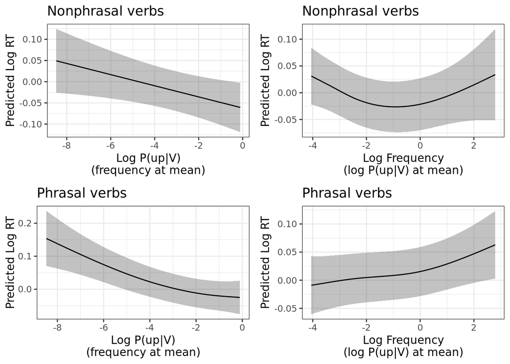

```r
conditions_cp = c('nonphrasal', 'phrasal')

slice_plots_cp = lapply(conditions_cp, function(cond) {
  base = tibble(Duration    = 0,
                trial       = gam_data_local$trial[1],
                participant = gam_data_local$participant[1],
                Item        = gam_data_local$Item[1],
                PhrasalVerb = factor(cond, levels = levels(gam_data_local$PhrasalVerb)))

  s_data = base %>%
    slice(rep(1, 200)) %>%
    mutate(log_cond_prob = seq(min(gam_data_local$log_cond_prob),
                               max(gam_data_local$log_cond_prob), length.out = 200),
           log_freq      = mean(gam_data_local$log_freq))
  ps = predict(mod_gam_phrasal_cond_prob, newdata = s_data, se.fit = TRUE, exclude = re_excl_cp2)
  s_data = s_data %>% mutate(fit = ps$fit, se = ps$se.fit)

  f_data = base %>%
    slice(rep(1, 200)) %>%
    mutate(log_freq      = seq(min(gam_data_local$log_freq),
                               max(gam_data_local$log_freq), length.out = 200),
           log_cond_prob = mean(gam_data_local$log_cond_prob))
  pf = predict(mod_gam_phrasal_cond_prob, newdata = f_data, se.fit = TRUE, exclude = re_excl_cp2)
  f_data = f_data %>% mutate(fit = pf$fit, se = pf$se.fit)

  ps_plot = ggplot(s_data, aes(x = log_cond_prob, y = fit)) +
    geom_ribbon(aes(ymin = fit - se, ymax = fit + se), alpha = 0.3) +
    geom_line() +
    xlab('Log P(up|V)\n(frequency at mean)') + ylab('Predicted Log RT') +
    ggtitle(paste0(tools::toTitleCase(cond), ' verbs')) +
    theme_bw()

  pf_plot = ggplot(f_data, aes(x = log_freq, y = fit)) +
    geom_ribbon(aes(ymin = fit - se, ymax = fit + se), alpha = 0.3) +
    geom_line() +
    xlab('Log Frequency\n(log P(up|V) at mean)') + ylab('Predicted Log RT') +
    ggtitle(paste0(tools::toTitleCase(cond), ' verbs')) +
    theme_bw()

  list(cond = ps_plot, freq = pf_plot)
})

ggarrange(slice_plots_cp[[1]]$cond, slice_plots_cp[[1]]$freq,
          slice_plots_cp[[2]]$cond, slice_plots_cp[[2]]$freq,
          nrow = 2, ncol = 2)
```

```r
rm(mod_gam_phrasal_cond_prob, pred_grid_cp, pred_grid_cp_nonphrasal, pred_grid_cp_phrasal,
   slice_plots_cp, preds_cp_nonphrasal, preds_cp_phrasal, z_cp_nonphrasal, z_cp_phrasal); gc()
```

```
##             used   (Mb) gc trigger   (Mb)  max used   (Mb)
## Ncells   6069233  324.2    9436887  504.0   9436887  504.0
## Vcells 470199225 3587.4  702387452 5358.8 877984315 6698.5
```

### Model 3: Main Effects and Interaction (ti() terms)

This model replicates the model from Equation 3 of the paper, replacing `log_predic` with `log_cond_prob`.

```r
mod_bam_inter_cond_prob = bam(log_rt ~
                                ti(log_freq) + ti(log_cond_prob) + ti(log_cond_prob, log_freq) +
                                Duration +
                                s(participant, bs = 're') +
                                s(Item, bs = 're') +
                                s(log_cond_prob, log_freq, participant, bs = 're'),
                              method = 'REML',
                              data = gam_data_local)

summary(mod_bam_inter_cond_prob)
```

```
##
## Family: gaussian
## Link function: identity
##
## Formula:
## log_rt ~ ti(log_freq) + ti(log_cond_prob) + ti(log_cond_prob,
##     log_freq) + Duration + s(participant, bs = "re") + s(Item,
##     bs = "re") + s(log_cond_prob, log_freq, participant, bs = "re")
##
## Parametric coefficients:
##             Estimate Std. Error t value Pr(>|t|)
## (Intercept)  0.05510    0.04043   1.363    0.173
## Duration    -1.82598    0.42984  -4.248 2.16e-05 ***
## ---
## Signif. codes:  0 '***' 0.001 '**' 0.01 '*' 0.05 '.' 0.1 ' ' 1
##
## Approximate significance of smooth terms:
##                                           edf  Ref.df      F p-value
## ti(log_freq)                            2.167   2.206  1.850  0.2431
## ti(log_cond_prob)                       1.871   1.908  4.234  0.0127 *
## ti(log_cond_prob,log_freq)              1.004   1.004  1.176  0.2793
## s(participant)                        296.207 305.000 38.256  <2e-16 ***
## s(Item)                               175.746 195.000 10.730  <2e-16 ***
## s(log_cond_prob,log_freq,participant)   7.768 305.000  0.041  0.4635
## ---
## Signif. codes:  0 '***' 0.001 '**' 0.01 '*' 0.05 '.' 0.1 ' ' 1
##
## R-sq.(adj) =  0.331   Deviance explained = 34.3%
## -REML =  17350  Scale est. = 0.20557   n = 26347
```

```r
saveRDS(mod_bam_inter_cond_prob, '../Models/mod_bam_inter_cond_prob.rds')
```

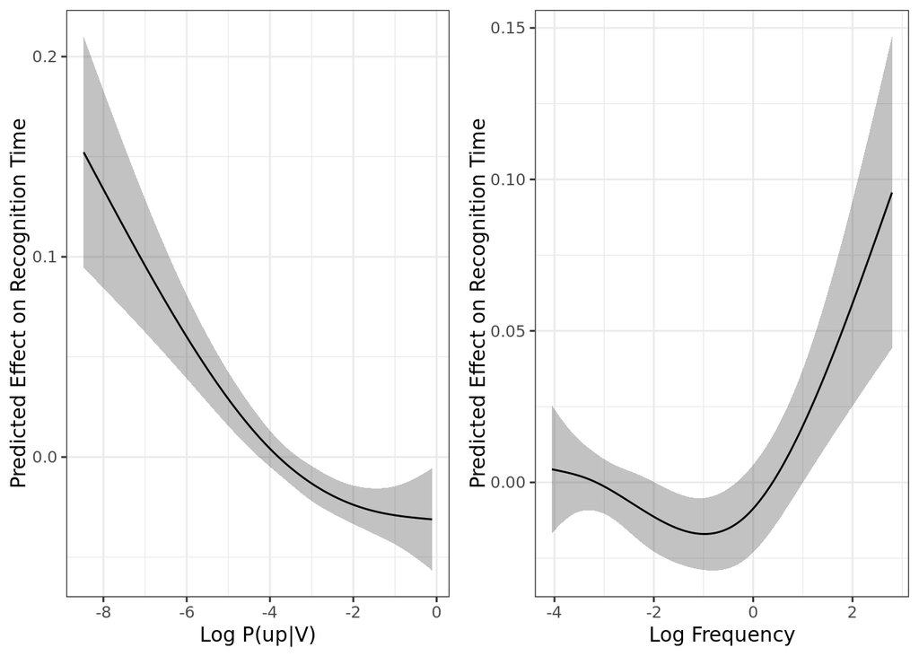

```r
nd_base_cp = tibble(Duration = 0, log_freq = 0, log_cond_prob = 0, participant = 0, Item = 0)

nd_cond = nd_base_cp %>%
  slice(rep(1, 1000)) %>%
  mutate(log_cond_prob = seq(min(gam_data_local$log_cond_prob),
                             max(gam_data_local$log_cond_prob), length.out = 1000))
nd_cond = predict(mod_bam_inter_cond_prob, newdata = nd_cond,
                  se = TRUE, terms = 'ti(log_cond_prob)') %>%
  as_tibble() %>% cbind(nd_cond)

nd_freq_cp = nd_base_cp %>%
  slice(rep(1, 1000)) %>%
  mutate(log_freq = seq(min(gam_data_local$log_freq), max(gam_data_local$log_freq), length.out = 1000))
nd_freq_cp = predict(mod_bam_inter_cond_prob, newdata = nd_freq_cp,
                     se = TRUE, terms = 'ti(log_freq)') %>%
  as_tibble() %>% cbind(nd_freq_cp)

p3_cond = ggplot(nd_cond, aes(x = log_cond_prob, y = fit)) +
  geom_ribbon(aes(ymin = fit - se.fit, ymax = fit + se.fit), alpha = 0.3) +
  geom_line() +
  xlab('Log P(up|V)') + ylab('Predicted Effect on Recognition Time') +
  theme_bw()

p3_freq_cp = ggplot(nd_freq_cp, aes(x = log_freq, y = fit)) +
  geom_ribbon(aes(ymin = fit - se.fit, ymax = fit + se.fit), alpha = 0.3) +
  geom_line() +
  xlab('Log Frequency') + ylab('Predicted Effect on Recognition Time') +
  theme_bw()

ggarrange(p3_cond, p3_freq_cp, nrow = 1)
```

```r
rm(mod_bam_inter_cond_prob, nd_base_cp, nd_cond, nd_freq_cp, p3_cond, p3_freq_cp); gc()
```

```
##             used   (Mb) gc trigger   (Mb)  max used   (Mb)
## Ncells   6054377  323.4    9436887  504.0   9436887  504.0
## Vcells 470216788 3587.5  842944942 6431.2 877984315 6698.5
```

## Bayesian Quadratic Models

Priors are identical to those used in the main paper.

### Full Model: Frequency and Log Conditional Probability

This model replicates Equation 4 of the paper, replacing `log_predic` with `log_cond_prob`.

$$\begin{aligned}
\log(RT) & \sim \log(\text{Frequency}) + \log P(up \mid V) + \text{Duration} \\
& + \log(\text{Frequency})^2 + \log P(up \mid V)^2 \\
& + (1 + \log(\text{Frequency}) + \log P(up \mid V) + \log(\text{Frequency})^2 \\
& \quad + \log P(up \mid V)^2 + \text{Duration} \mid\mid \text{Participant}) + (1 \mid\mid \text{Item})
\end{aligned}$$

```r
brms_cond_prob_quadratic = value(future_cp_full)
fixef(brms_cond_prob_quadratic)
```

```
##                      Estimate   Est.Error          Q2.5        Q97.5
## Intercept        -0.090530141 0.038144482 -0.1649027918 -0.016444213
## log_freq          0.020105063 0.010913473 -0.0015657717  0.041463795
## log_cond_prob     0.018336306 0.018283806 -0.0174888775  0.054054642
## Duration         -0.086952689 0.097350288 -0.2771698049  0.105230326
## Ilog_cond_probE2  0.004355802 0.002460160 -0.0004295994  0.009200563
## Ilog_freqE2       0.005522044 0.003592845 -0.0015067585  0.012599432
```

```r
percent_greater_zero_cp = data.frame(fixef(brms_cond_prob_quadratic, summary = FALSE)) %>%
  pivot_longer(cols = everything(), names_to = 'beta_coefficient', values_to = 'estimate') %>%
  group_by(beta_coefficient) %>%
  summarize(pct_gt_zero = (sum(estimate > 0) / n()) * 100)

percent_greater_zero_cp
```

```
## # A tibble: 6 x 2
##   beta_coefficient pct_gt_zero
##   <chr>                  <dbl>
## 1 Duration              18.6
## 2 Ilog_cond_probE2      96.2
## 3 Ilog_freqE2           93.9
## 4 Intercept              0.835
## 5 log_cond_prob         84.3
## 6 log_freq              96.6
```

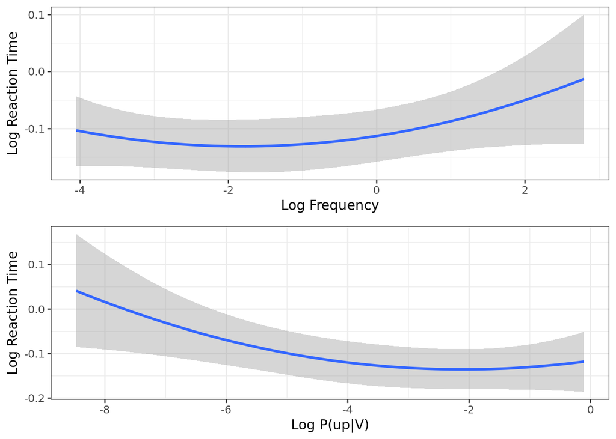

```r
brms_cp_plot = conditional_effects(brms_cond_prob_quadratic)

freq_plot_cp = plot(brms_cp_plot, plot = FALSE)[[1]] +
  ylab('Log Reaction Time') + xlab('Log Frequency') + theme_bw()

cond_prob_plot = plot(brms_cp_plot, plot = FALSE)[[2]] +
  ylab('Log Reaction Time') + xlab('Log P(up|V)') + theme_bw()

ggarrange(freq_plot_cp, cond_prob_plot, nrow = 2, ncol = 1)
```

[figure not shown]

```r
beta_coef_labels_cp = list.reverse(c('log P(up|V)', 'log-frequency', 'Intercept',
                                     'log P(up|V)^2', 'log-frequency^2'))
brms_cond_prob_quadratic %>%
  gather_draws(b_Intercept, b_log_freq, b_log_cond_prob,
               b_Ilog_cond_probE2, b_Ilog_freqE2) %>%
  ggplot(aes(x = .value, y = .variable)) +
  stat_halfeye() +
  xlab('Posterior Distribution') +
  ylab('Beta Coefficient') +
  scale_y_discrete(labels = beta_coef_labels_cp) +
  theme_bw()
```

```r
rm(brms_cond_prob_quadratic, brms_cp_plot, percent_greater_zero_cp,
   freq_plot_cp, cond_prob_plot); gc()
```

```
##             used   (Mb) gc trigger    (Mb)   max used    (Mb)
## Ncells   6555275  350.1   11555052   617.2   11555052   617.2
## Vcells 657449422 5016.0 1322623143 10090.9 1322623143 10090.9
```

### Log Conditional Probability-Only Model

This model replicates Equation 5 of the paper (the predictability-only quadratic), replacing `log_predic` with `log_cond_prob`.

$$\begin{aligned}
\log(RT) & \sim \log P(up \mid V) + \text{Duration} + \log P(up \mid V)^2 \\
& + (1 + \log P(up \mid V) + \log P(up \mid V)^2 + \text{Duration} \mid\mid \text{Participant}) + (1 \mid\mid \text{Item})
\end{aligned}$$

```r
brms_cond_prob_only_quadratic = value(future_cp_only)

fixef(brms_cond_prob_only_quadratic)
```

```
##                      Estimate   Est.Error         Q2.5        Q97.5
## Intercept        -0.097239873 0.034759909 -0.166820103 -0.029945406
## log_cond_prob     0.013361293 0.017835484 -0.021549783  0.047982855
## Duration         -0.089496844 0.096838690 -0.280271092  0.099312698
## Ilog_cond_probE2  0.003598344 0.002366945 -0.001009846  0.008195834
```

```r
post_samples_cp_only = as.data.frame(fixef(brms_cond_prob_only_quadratic, summary = FALSE)) %>%
  select(log_cond_prob, Ilog_cond_probE2)

cat("% samples log_cond_prob^2 > 0:",
    round(sum(post_samples_cp_only$Ilog_cond_probE2 > 0) /
            nrow(post_samples_cp_only) * 100, 1), "\n")
```

```
## % samples log_cond_prob^2 > 0: 93.7
```

```r
cat("% samples log_cond_prob > 0:",
    round(sum(post_samples_cp_only$log_cond_prob > 0) /
            nrow(post_samples_cp_only) * 100, 1), "\n")
```

```
## % samples log_cond_prob > 0: 77.4
```

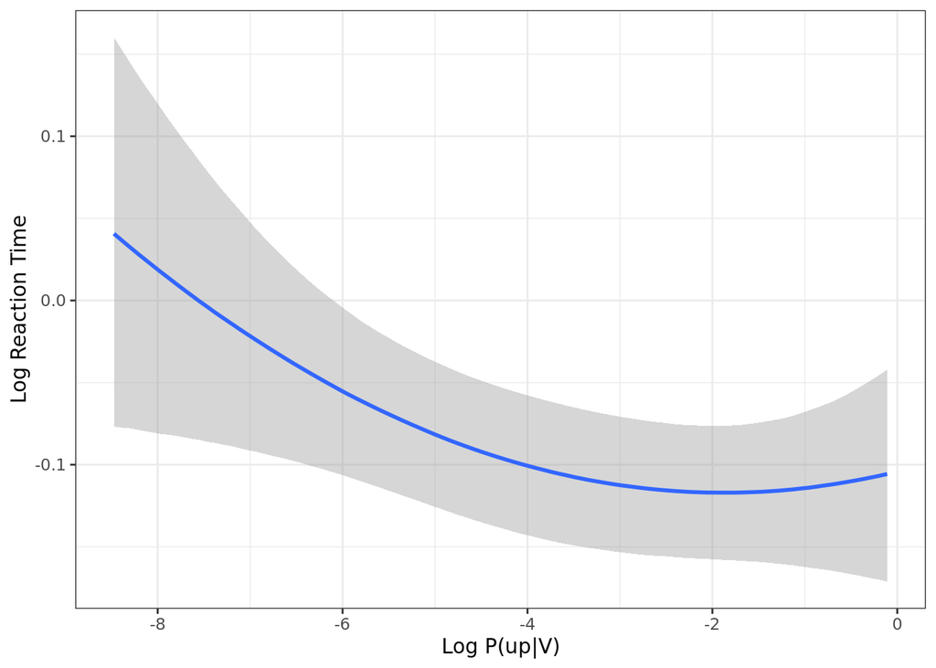

```r
brms_cp_only_plot = conditional_effects(brms_cond_prob_only_quadratic)

plot(brms_cp_only_plot, plot = FALSE)[[1]] +
  ylab('Log Reaction Time') +
  xlab('Log P(up|V)') +
  theme_bw()
```

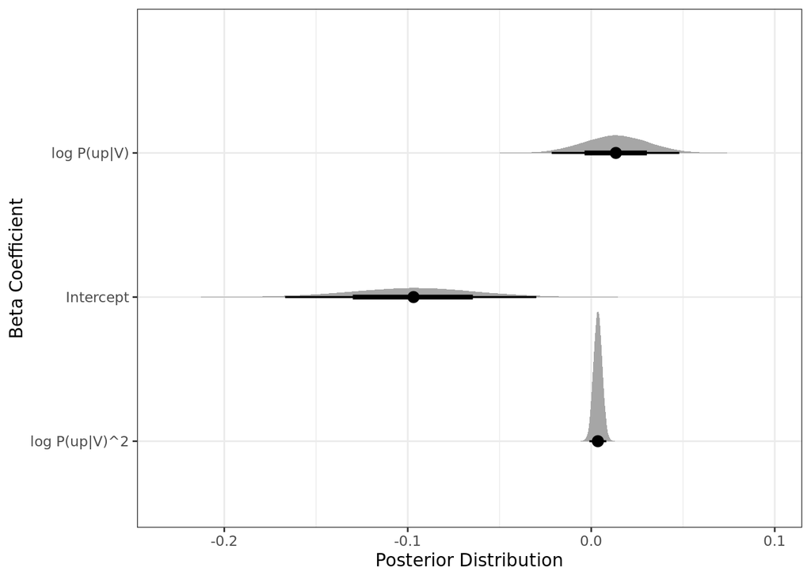

```r
beta_coef_labels_cp_only = list.reverse(c('log P(up|V)', 'Intercept', 'log P(up|V)^2'))
brms_cond_prob_only_quadratic %>%
  gather_draws(b_Intercept, b_log_cond_prob, b_Ilog_cond_probE2) %>%
  ggplot(aes(x = .value, y = .variable)) +
  stat_halfeye() +
  xlab('Posterior Distribution') +
  ylab('Beta Coefficient') +
  scale_y_discrete(labels = beta_coef_labels_cp_only) +
  theme_bw()
```

```r
rm(brms_cond_prob_only_quadratic, brms_cp_only_plot, post_samples_cp_only); gc()
```

```
##             used   (Mb) gc trigger    (Mb)   max used    (Mb)
## Ncells   6993697  373.6   11555052   617.2   11555052   617.2
## Vcells 793741910 6055.8 1322623143 10090.9 1322623143 10090.9
```

## Robustness Check: Correlated Random Effects with LKJ Priors

These models replicate the two log conditional probability Bayesian models above with correlated random effects and an LKJ(2) prior on the correlation matrix, mirroring the robustness check for the original paper’s models.

### Full Model: Frequency and Log Conditional Probability with LKJ Priors

```r
brms_cond_prob_quadratic_lkj = value(future_cp_lkj_full)

fixef(brms_cond_prob_quadratic_lkj)
```

```
##                      Estimate   Est.Error          Q2.5        Q97.5
## Intercept        -0.090504396 0.038152168 -0.1656156102 -0.015385454
## log_freq          0.020778718 0.011091224 -0.0009010186  0.042892674
## log_cond_prob     0.018637626 0.018413315 -0.0175404244  0.054702769
## Duration         -0.086223695 0.098866917 -0.2802726804  0.106755665
## Ilog_cond_probE2  0.004402416 0.002476219 -0.0004771004  0.009234483
## Ilog_freqE2       0.005693255 0.003614206 -0.0013877411  0.012802980
```

```r
percent_greater_zero_cp_lkj = data.frame(fixef(brms_cond_prob_quadratic_lkj, summary = FALSE)) %>%
  pivot_longer(cols = everything(), names_to = 'beta_coefficient', values_to = 'estimate') %>%
  group_by(beta_coefficient) %>%
  summarize(pct_gt_zero = (sum(estimate > 0) / n()) * 100)

percent_greater_zero_cp_lkj
```

```
## # A tibble: 6 x 2
##   beta_coefficient pct_gt_zero
##   <chr>                  <dbl>
## 1 Duration              19.2
## 2 Ilog_cond_probE2      96.2
## 3 Ilog_freqE2           94.2
## 4 Intercept              0.913
## 5 log_cond_prob         84.5
## 6 log_freq              97.0
```

[figure not shown]

```r
beta_coef_labels_cp_lkj = list.reverse(c('log P(up|V)', 'log-frequency', 'Intercept',
                                          'log P(up|V)^2', 'log-frequency^2'))
brms_cond_prob_quadratic_lkj %>%
  gather_draws(b_Intercept, b_log_freq, b_log_cond_prob,
               b_Ilog_cond_probE2, b_Ilog_freqE2) %>%
  ggplot(aes(x = .value, y = .variable)) +
  stat_halfeye() +
  xlab('Posterior Distribution') +
  ylab('Beta Coefficient') +
  scale_y_discrete(labels = beta_coef_labels_cp_lkj) +
  theme_bw()
```

```r
rm(brms_cond_prob_quadratic_lkj, percent_greater_zero_cp_lkj); gc()
```

```
##              used   (Mb) gc trigger    (Mb)   max used    (Mb)
## Ncells    7435508  397.1   11555052   617.2   11555052   617.2
## Vcells 1069134683 8156.9 2026535580 15461.3 1688712984 12883.9
```

### Log Conditional Probability-Only Model with LKJ Priors

```r
brms_cond_prob_only_quadratic_lkj = value(future_cp_lkj_only)
fixef(brms_cond_prob_only_quadratic_lkj)
```

```
##                      Estimate   Est.Error         Q2.5        Q97.5
## Intercept        -0.098589863 0.035004946 -0.167394493 -0.030766200
## log_cond_prob     0.013218169 0.017908485 -0.021672233  0.048211031
## Duration         -0.089306951 0.098343567 -0.282311502  0.102902091
## Ilog_cond_probE2  0.003580285 0.002375203 -0.001094763  0.008236379
```

```r
post_samples_cp_lkj_only = as.data.frame(fixef(brms_cond_prob_only_quadratic_lkj, summary = FALSE)) %>%
  select(log_cond_prob, Ilog_cond_probE2)

cat("% samples log_cond_prob^2 > 0:",
    round(sum(post_samples_cp_lkj_only$Ilog_cond_probE2 > 0) /
            nrow(post_samples_cp_lkj_only) * 100, 1), "\n")
```

```
## % samples log_cond_prob^2 > 0: 93.4
```

```r
cat("% samples log_cond_prob > 0:",
    round(sum(post_samples_cp_lkj_only$log_cond_prob > 0) /
            nrow(post_samples_cp_lkj_only) * 100, 1), "\n")
```

```
## % samples log_cond_prob > 0: 77
```

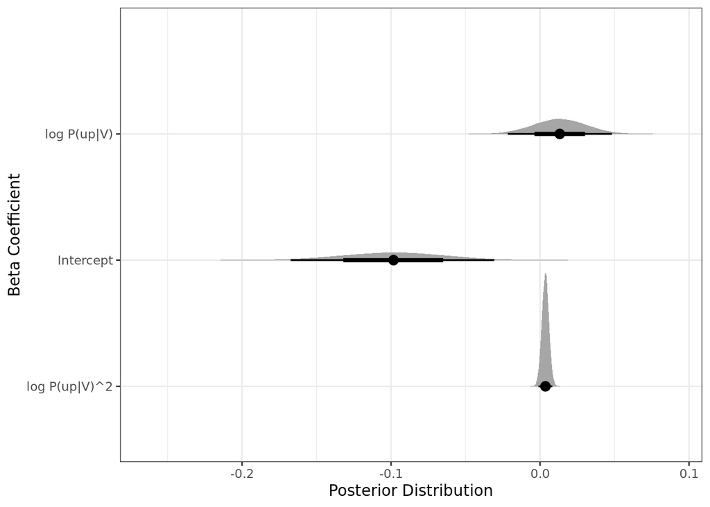

```r
beta_coef_labels_cp_lkj_only = list.reverse(c('log P(up|V)', 'Intercept', 'log P(up|V)^2'))
brms_cond_prob_only_quadratic_lkj %>%
  gather_draws(b_Intercept, b_log_cond_prob, b_Ilog_cond_probE2) %>%
  ggplot(aes(x = .value, y = .variable)) +
  stat_halfeye() +
  xlab('Posterior Distribution') +
  ylab('Beta Coefficient') +
  scale_y_discrete(labels = beta_coef_labels_cp_lkj_only) +
  theme_bw()
```

```r
rm(brms_cond_prob_only_quadratic_lkj, post_samples_cp_lkj_only,
   gam_data_local, gam_data_orig); gc()
```

```
##              used   (Mb) gc trigger    (Mb)   max used    (Mb)
## Ncells    7874013  420.6   11555052   617.2   11555052   617.2
## Vcells 1209654731 9229.0 2026535580 15461.3 1813495358 13835.9
```